# Data Preparation

```python
## Load TEDS-D 2017 Data into a Pandas Data Frame
import pandas as pd
import seaborn as sns
from matplotlib import pyplot as plt
import numpy as np
from os.path import exists
import os

## Specify WD
wd = "/home/abf/BINF667013_Final_Project/"
#wd = (
#    "/Users/adam/Documents/BINF667013_BigDataAnalyticsHealthcare/" +
#    "Final_Project/TEDS_Study"
#)
os.chdir(wd)

if exists("analysis_objects/teds_laws.csv"):
    teds_laws=pd.read_csv("analysis_objects/teds_laws.csv")
else:
    print("Generate Clean Dataset First")
if exists("analysis_objects/teds_imp_laws.csv"):
    teds_imp_laws=pd.read_csv("analysis_objects/teds_imp_laws.csv")
else:
    print("Generate Clean Dataset First")
```

# Exploratory Data Analysis

### Primary Substance by IC Legal Status

```python
totals=teds_laws.loc[:,['IC_law', 'SUB1']].assign(
    No_substance = lambda x: x.loc[:,['SUB1']].apply(lambda x: x['SUB1'] == 1, axis=1),
    Alcohol = lambda x: x.loc[:,['SUB1']].apply(lambda x: x['SUB1'] == 2, axis=1),
    Cocaine = lambda x: x.loc[:,['SUB1']].apply(lambda x: x['SUB1'] == 3, axis=1),
    Marijuana = lambda x: x.loc[:,['SUB1']].apply(lambda x: x['SUB1'] == 4, axis=1),
    Heroin = lambda x: x.loc[:,['SUB1']].apply(lambda x: x['SUB1'] == 5, axis=1),
    NP_Methadone = lambda x: x.loc[:,['SUB1']].apply(lambda x: x['SUB1'] == 6, axis=1),
    OthOpiate = lambda x: x.loc[:,['SUB1']].apply(lambda x: x['SUB1'] == 7, axis=1),
    PCP = lambda x: x.loc[:,['SUB1']].apply(lambda x: x['SUB1'] == 7, axis=1),
    Hallucinogen = lambda x: x.loc[:,['SUB1']].apply(lambda x: x['SUB1'] == 9, axis=1),
    Methamphetamine = lambda x: x.loc[:,['SUB1']].apply(lambda x: x['SUB1'] == 10, axis=1),
    OthAmphet = lambda x: x.loc[:,['SUB1']].apply(lambda x: x['SUB1'] == 11, axis=1),
    OthStim = lambda x: x.loc[:,['SUB1']].apply(lambda x: x['SUB1'] == 12, axis=1),
    Benzo = lambda x: x.loc[:,['SUB1']].apply(lambda x: x['SUB1'] == 13, axis=1),
    OthTranq = lambda x: x.loc[:,['SUB1']].apply(lambda x: x['SUB1'] == 14, axis=1),
    Barbituates = lambda x: x.loc[:,['SUB1']].apply(lambda x: x['SUB1'] == 15, axis=1),
    OthSed = lambda x: x.loc[:,['SUB1']].apply(lambda x: x['SUB1'] == 16, axis=1),
    Inhalants = lambda x: x.loc[:,['SUB1']].apply(lambda x: x['SUB1'] == 17, axis=1),
    OTC_Med = lambda x: x.loc[:,['SUB1']].apply(lambda x: x['SUB1'] == 18, axis=1),
    Other = lambda x: x.loc[:,['SUB1']].apply(lambda x: x['SUB1'] == 19, axis=1),

).groupby(['IC_law']).sum().drop(columns=['SUB1'])
totals
```

| IC_law | No_substance | Alcohol | Cocaine | Marijuana | Heroin | NP_Methadone | OthOpiate | PCP | Hallucinogen | Methamphetamine | OthAmphet | OthStim | Benzo | OthTranq | Barbituates | OthSed | Inhalants | OTC_Med | Other |
| --- | --- | --- | --- | --- | --- | --- | --- | --- | --- | --- | --- | --- | --- | --- | --- | --- | --- | --- | --- |
| 0 | 1342 | 110450 | 26356 | 56127 | 107411 | 359 | 20158 | 20158 | 462 | 21121 | 1065 | 378 | 4225 | 18 | 395 | 399 | 146 | 160 | 1229 |
| 1 | 15146 | 281733 | 47999 | 109479 | 190656 | 2507 | 85975 | 85975 | 1099 | 92964 | 5662 | 1150 | 10496 | 88 | 200 | 1165 | 522 | 400 | 4875 |

```python
totals.div(totals.sum(axis=1), axis=0).reset_index()
```

|  | IC_law | No_substance | Alcohol | Cocaine | Marijuana | Heroin | NP_Methadone | OthOpiate | PCP | Hallucinogen | Methamphetamine | OthAmphet | OthStim | Benzo | OthTranq | Barbituates | OthSed | Inhalants | OTC_Med | Other |
| --- | --- | --- | --- | --- | --- | --- | --- | --- | --- | --- | --- | --- | --- | --- | --- | --- | --- | --- | --- | --- |
| 0 | 0 | 0.003608 | 0.296941 | 0.070857 | 0.150896 | 0.288771 | 0.000965 | 0.054194 | 0.054194 | 0.001242 | 0.056783 | 0.002863 | 0.001016 | 0.011359 | 0.000048 | 0.001062 | 0.001073 | 0.000393 | 0.000430 | 0.003304 |
| 1 | 1 | 0.016146 | 0.300326 | 0.051167 | 0.116704 | 0.203238 | 0.002672 | 0.091649 | 0.091649 | 0.001172 | 0.099099 | 0.006036 | 0.001226 | 0.011189 | 0.000094 | 0.000213 | 0.001242 | 0.000556 | 0.000426 | 0.005197 |

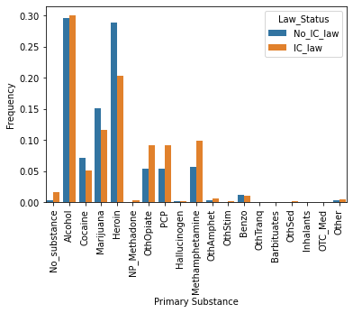

```python
plt.xticks(rotation=90)
sns.barplot(
    data=pd.melt(
        totals.div(totals.sum(axis=1), axis=0).reset_index(),
        id_vars = 'IC_law',
        value_vars = [
             'No_substance','Alcohol','Cocaine','Marijuana','Heroin',
             'NP_Methadone', 'OthOpiate', 'PCP', 'Hallucinogen',
             'Methamphetamine','OthAmphet','OthStim','Benzo','OthTranq',
             'Barbituates','OthSed','Inhalants','OTC_Med','Other'
        ],
        var_name = "Primary Substance",
        value_name = "Frequency"
    ).assign(
        Law_Status = lambda x: x.apply(lambda y: 'No_IC_law' if y['IC_law'] == 0 else 'IC_law', axis=1)
    ),
    x="Primary Substance",
    y="Frequency",
    hue="Law_Status",

)
```

```python
totals.div(totals.sum(axis=0), axis=1).reset_index()
```

|  | IC_law | No_substance | Alcohol | Cocaine | Marijuana | Heroin | NP_Methadone | OthOpiate | PCP | Hallucinogen | Methamphetamine | OthAmphet | OthStim | Benzo | OthTranq | Barbituates | OthSed | Inhalants | OTC_Med | Other |
| --- | --- | --- | --- | --- | --- | --- | --- | --- | --- | --- | --- | --- | --- | --- | --- | --- | --- | --- | --- | --- |
| 0 | 0 | 0.081393 | 0.281629 | 0.354462 | 0.338919 | 0.360359 | 0.125262 | 0.189932 | 0.189932 | 0.295964 | 0.185134 | 0.158317 | 0.247382 | 0.287005 | 0.169811 | 0.663866 | 0.255115 | 0.218563 | 0.285714 | 0.201343 |
| 1 | 1 | 0.918607 | 0.718371 | 0.645538 | 0.661081 | 0.639641 | 0.874738 | 0.810068 | 0.810068 | 0.704036 | 0.814866 | 0.841683 | 0.752618 | 0.712995 | 0.830189 | 0.336134 | 0.744885 | 0.781437 | 0.714286 | 0.798657 |

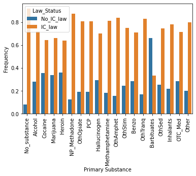

```python
plt.xticks(rotation=90)
sns.barplot(
    data=pd.melt(
        totals.div(totals.sum(axis=0), axis=1).reset_index(),
        id_vars = 'IC_law',
        value_vars = [
             'No_substance','Alcohol','Cocaine','Marijuana','Heroin',
             'NP_Methadone', 'OthOpiate', 'PCP', 'Hallucinogen',
             'Methamphetamine','OthAmphet','OthStim','Benzo','OthTranq',
             'Barbituates','OthSed','Inhalants','OTC_Med','Other'
        ],
        var_name = "Primary Substance",
        value_name = "Frequency"
    ).assign(
        Law_Status = lambda x: x.apply(lambda y: 'No_IC_law' if y['IC_law'] == 0 else 'IC_law', axis=1)
    ),
    x="Primary Substance",
    y="Frequency",
    hue="Law_Status",

)
```

### Summarize Relapses by IC Legal Status And Drug

Cases where the primary substance at admission is still being used at discharge will be considered relapses

```python
teds_laws.groupby(['IC_law']).sum().loc[:,['alc_cases','hrn_cases', 'met_cases','alc_relapse','hrn_relapse', 'met_relapse']].assign(
    alc_rate = lambda x: x['alc_relapse'] / x['alc_cases'],
    hrn_rate = lambda x: x['hrn_relapse'] / x['hrn_cases'],
    met_rate = lambda x: x['met_relapse'] / x['met_cases']
)
```

| IC_law | alc_cases | hrn_cases | met_cases | alc_relapse | hrn_relapse | met_relapse | alc_rate | hrn_rate | met_rate |
| --- | --- | --- | --- | --- | --- | --- | --- | --- | --- |
| 0 | 110450 | 107411 | 21121 | 95971 | 90140 | 20678 | 0.868909 | 0.839206 | 0.979026 |
| 1 | 281733 | 190656 | 92964 | 277450 | 188729 | 89536 | 0.984798 | 0.989893 | 0.963126 |

```python
teds_imp_laws.groupby(['IC_law']).sum().loc[:,['alc_cases','hrn_cases', 'met_cases','alc_relapse','hrn_relapse', 'met_relapse']].assign(
    alc_rate = lambda x: x['alc_relapse'] / x['alc_cases'],
    hrn_rate = lambda x: x['hrn_relapse'] / x['hrn_cases'],
    met_rate = lambda x: x['met_relapse'] / x['met_cases']
)
```

| IC_law | alc_cases | hrn_cases | met_cases | alc_relapse | hrn_relapse | met_relapse | alc_rate | hrn_rate | met_rate |
| --- | --- | --- | --- | --- | --- | --- | --- | --- | --- |
| 0 | 110450 | 107411 | 21121 | 95971 | 90140 | 20678 | 0.868909 | 0.839206 | 0.979026 |
| 1 | 281733 | 190656 | 92964 | 277450 | 188729 | 89536 | 0.984798 | 0.989893 | 0.963126 |

```
   IC_law  alc_cases  alc_relapse  relapse_rate  total
0       0     110450        95971     86.890901    100
1       1     281733       277450     98.479766    100
```

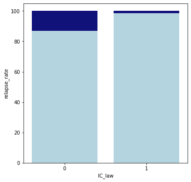

```python
## Index casese of alcohol use at intake
alc_cases = teds_laws.alc_cases == 1

plt.figure(figsize=(6, 6))
plot_data = teds_laws.loc[
    alc_cases,['IC_law','alc_cases','alc_relapse']
].groupby(['IC_law']).sum().reset_index().assign(
    relapse_rate = lambda x: 100*(x['alc_relapse'] / x['alc_cases']),
    total = [100, 100]
)
print(plot_data)
total_bars = sns.barplot(
    x="IC_law",
    y="total",
    data=plot_data,
    color='darkblue'
)

rate_bars = sns.barplot(
    x="IC_law",
    y="relapse_rate",
    data=plot_data,
    color='lightblue'
)
plt.show()
```

```
   IC_law  alc_cases  alc_relapse  relapse_rate  total
0       0     110450        95971     86.890901    100
1       1     281733       277450     98.479766    100
```

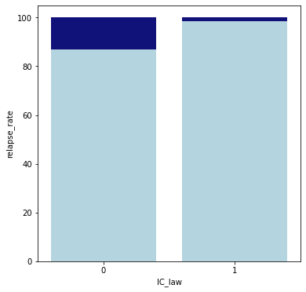

```python
## Index casese of alcohol use at intake
alc_cases = teds_imp_laws.alc_cases == 1
plt.figure(figsize=(6, 6))
plot_data = teds_imp_laws.loc[
    alc_cases,['IC_law','alc_cases','alc_relapse']
].groupby(['IC_law']).sum().reset_index().assign(
    relapse_rate = lambda x: 100*(x['alc_relapse'] / x['alc_cases']),
    total = [100, 100]
)
print(plot_data)
total_bars = sns.barplot(
    x="IC_law",
    y="total",
    data=plot_data,
    color='darkblue'
)

rate_bars = sns.barplot(
    x="IC_law",
    y="relapse_rate",
    data=plot_data,
    color='lightblue'
)
plt.show()
```

```
   IC_law  hrn_cases  hrn_relapse  relapse_rate  total
0       0     107411        90140     83.920641    100
1       1     190656       188729     98.989279    100
```

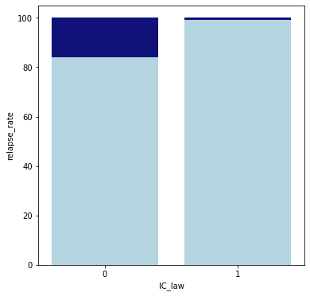

```python
## Index casese of heroin use at intake
hrn_cases = teds_laws.hrn_cases == 1
plt.figure(figsize=(6, 6))
plot_data = teds_laws.loc[
    hrn_cases,['IC_law','hrn_cases','hrn_relapse']
].groupby(['IC_law']).sum().reset_index().assign(
    relapse_rate = lambda x: 100*(x['hrn_relapse'] / x['hrn_cases']),
    total = [100, 100]
)
print(plot_data)
total_bars = sns.barplot(
    x="IC_law",
    y="total",
    data=plot_data,
    color='darkblue'
)

rate_bars = sns.barplot(
    x="IC_law",
    y="relapse_rate",
    data=plot_data,
    color='lightblue'
)
plt.show()
```

```
   IC_law  hrn_cases  hrn_relapse  relapse_rate  total
0       0     107411        90140     83.920641    100
1       1     190656       188729     98.989279    100
```

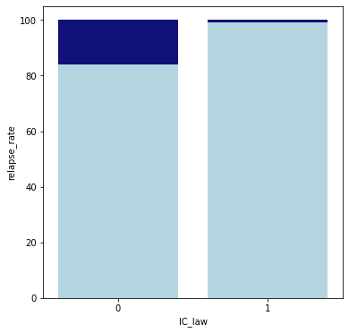

```python
## Index casese of alcohol use at intake
hrn_cases = teds_imp_laws.hrn_cases == 1
plt.figure(figsize=(6, 6))
plot_data = teds_imp_laws.loc[
    hrn_cases,['IC_law','hrn_cases','hrn_relapse']
].groupby(['IC_law']).sum().reset_index().assign(
    relapse_rate = lambda x: 100*(x['hrn_relapse'] / x['hrn_cases']),
    total = [100, 100]
)
print(plot_data)
total_bars = sns.barplot(
    x="IC_law",
    y="total",
    data=plot_data,
    color='darkblue'
)

rate_bars = sns.barplot(
    x="IC_law",
    y="relapse_rate",
    data=plot_data,
    color='lightblue'
)
plt.show()
```

```
   IC_law  met_cases  met_relapse  relapse_rate  total
0       0      21121        20678     97.902561    100
1       1      92964        89536     96.312551    100
```

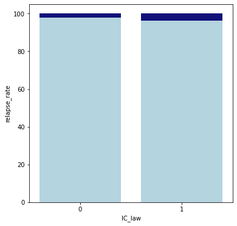

```python
## Index casese of methamphetamine use at intake
met_cases = teds_laws.met_cases == 1

plt.figure(figsize=(6, 6))
plot_data = teds_laws.loc[
    met_cases,['IC_law','met_cases','met_relapse']
].groupby(['IC_law']).sum().reset_index().assign(
    relapse_rate = lambda x: 100*(x['met_relapse'] / x['met_cases']),
    total = [100, 100]
)
print(plot_data)
total_bars = sns.barplot(
    x="IC_law",
    y="total",
    data=plot_data,
    color='darkblue'
)

rate_bars = sns.barplot(
    x="IC_law",
    y="relapse_rate",
    data=plot_data,
    color='lightblue'
)
plt.show()
```

```
   IC_law  met_cases  met_relapse  relapse_rate  total
0       0      21121        20678     97.902561    100
1       1      92964        89536     96.312551    100
```

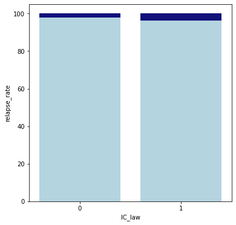

```python
## Index casese of methamphetamine use at intake
met_cases = teds_imp_laws.met_cases == 1

plt.figure(figsize=(6, 6))
plot_data = teds_imp_laws.loc[
    met_cases,['IC_law','met_cases','met_relapse']
].groupby(['IC_law']).sum().reset_index().assign(
    relapse_rate = lambda x: 100*(x['met_relapse'] / x['met_cases']),
    total = [100, 100]
)
print(plot_data)
total_bars = sns.barplot(
    x="IC_law",
    y="total",
    data=plot_data,
    color='darkblue'
)

rate_bars = sns.barplot(
    x="IC_law",
    y="relapse_rate",
    data=plot_data,
    color='lightblue'
)
plt.show()
```

### IC Laws and Referral Source

**Total Cases in Each Category by IC Law, for Alcohol Patients**

```python
alc_cases = teds_laws.alc_cases == 1
totals=teds_laws.loc[alc_cases,['IC_law', 'PSOURCE']].assign(
    individual = lambda x: x.loc[:,['PSOURCE']].apply(lambda x: x['PSOURCE'] == 1, axis=1),
    treatment = lambda x: x.loc[:,['PSOURCE']].apply(lambda x: x['PSOURCE'] == 2, axis=1),
    health = lambda x: x.loc[:,['PSOURCE']].apply(lambda x: x['PSOURCE'] == 3, axis=1),
    school = lambda x: x.loc[:,['PSOURCE']].apply(lambda x: x['PSOURCE'] == 4, axis=1),
    employer = lambda x: x.loc[:,['PSOURCE']].apply(lambda x: x['PSOURCE'] == 5, axis=1),
    community = lambda x: x.loc[:,['PSOURCE']].apply(lambda x: x['PSOURCE'] == 6, axis=1),
    adjudicated = lambda x: x.loc[:,['PSOURCE']].apply(lambda x: x['PSOURCE'] == 7, axis=1)
).groupby(['IC_law']).sum().drop(columns=['PSOURCE'])
totals
```

| IC_law | individual | treatment | health | school | employer | community | adjudicated |
| --- | --- | --- | --- | --- | --- | --- | --- |
| 0 | 36000 | 14169 | 9258 | 152 | 1387 | 13539 | 35945 |
| 1 | 113480 | 27077 | 29691 | 513 | 1085 | 29201 | 80686 |

**Alcohol Patients: Proportion Cases in each referal category by IC Laws**

```python
 totals.div(totals.sum(axis=1), axis=0).reset_index()
```

|  | IC_law | individual | treatment | health | school | employer | community | adjudicated |
| --- | --- | --- | --- | --- | --- | --- | --- | --- |
| 0 | 0 | 0.325939 | 0.128284 | 0.083821 | 0.001376 | 0.012558 | 0.122580 | 0.325441 |
| 1 | 1 | 0.402793 | 0.096109 | 0.105387 | 0.001821 | 0.003851 | 0.103648 | 0.286392 |

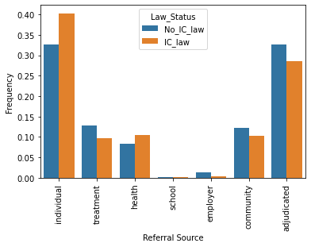

```python
plt.xticks(rotation=90)
sns.barplot(
    data=pd.melt(
        totals.div(totals.sum(axis=1), axis=0).reset_index(),
        id_vars = 'IC_law',
        value_vars = ['individual', 'treatment', 'health', 'school', 'employer', 'community', 'adjudicated'],
        var_name = "Referral Source",
        value_name = "Frequency"
    ).assign(
        Law_Status = lambda x: x.apply(lambda y: 'No_IC_law' if y['IC_law'] == 0 else 'IC_law', axis=1)
    ),
    x="Referral Source",
    y="Frequency",
    hue="Law_Status",

)
```

**Alcohol Patients: Proportion of cases in each Referal category that are subject to IC Laws**

```python
totals.div(totals.sum(axis=0), axis=1).reset_index()
```

|  | IC_law | individual | treatment | health | school | employer | community | adjudicated |
| --- | --- | --- | --- | --- | --- | --- | --- | --- |
| 0 | 0 | 0.240835 | 0.343524 | 0.237695 | 0.228571 | 0.561084 | 0.316776 | 0.308194 |
| 1 | 1 | 0.759165 | 0.656476 | 0.762305 | 0.771429 | 0.438916 | 0.683224 | 0.691806 |

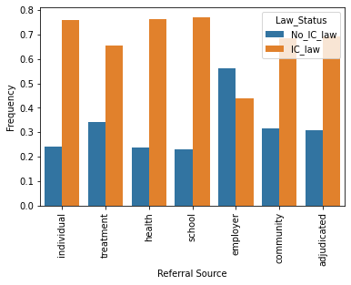

```python
plt.xticks(rotation=90)
sns.barplot(
    data=pd.melt(
        totals.div(totals.sum(axis=0), axis=1).reset_index(),
        id_vars = 'IC_law',
        value_vars = ['individual', 'treatment', 'health', 'school', 'employer', 'community', 'adjudicated'],
        var_name = "Referral Source",
        value_name = "Frequency"
    ).assign(
        Law_Status = lambda x: x.apply(lambda y: 'No_IC_law' if y['IC_law'] == 0 else 'IC_law', axis=1)
    ),
    x="Referral Source",
    y="Frequency",
    hue="Law_Status",

)
```

**Total Cases in Each Category by IC Law, for Heroin Patients**

```python
hrn_cases = teds_laws.hrn_cases == 1
totals=teds_laws.loc[hrn_cases,['IC_law', 'PSOURCE']].assign(
    individual = lambda x: x.loc[:,['PSOURCE']].apply(lambda x: x['PSOURCE'] == 1, axis=1),
    treatment = lambda x: x.loc[:,['PSOURCE']].apply(lambda x: x['PSOURCE'] == 2, axis=1),
    health = lambda x: x.loc[:,['PSOURCE']].apply(lambda x: x['PSOURCE'] == 3, axis=1),
    school = lambda x: x.loc[:,['PSOURCE']].apply(lambda x: x['PSOURCE'] == 4, axis=1),
    employer = lambda x: x.loc[:,['PSOURCE']].apply(lambda x: x['PSOURCE'] == 5, axis=1),
    community = lambda x: x.loc[:,['PSOURCE']].apply(lambda x: x['PSOURCE'] == 6, axis=1),
    adjudicated = lambda x: x.loc[:,['PSOURCE']].apply(lambda x: x['PSOURCE'] == 7, axis=1)
).groupby(['IC_law']).sum().drop(columns=['PSOURCE'])
totals
```

| IC_law | individual | treatment | health | school | employer | community | adjudicated |
| --- | --- | --- | --- | --- | --- | --- | --- |
| 0 | 47561 | 21489 | 4607 | 25 | 219 | 9851 | 23659 |
| 1 | 111759 | 28749 | 11196 | 116 | 301 | 12660 | 25875 |

**Heroin Patients: Proportion Cases in each referal category by IC Laws**

```python
 totals.div(totals.sum(axis=1), axis=0).reset_index()
```

|  | IC_law | individual | treatment | health | school | employer | community | adjudicated |
| --- | --- | --- | --- | --- | --- | --- | --- | --- |
| 0 | 0 | 0.442794 | 0.200063 | 0.042891 | 0.000233 | 0.002039 | 0.091713 | 0.220266 |
| 1 | 1 | 0.586181 | 0.150790 | 0.058724 | 0.000608 | 0.001579 | 0.066402 | 0.135716 |

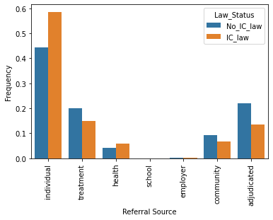

```python
plt.xticks(rotation=90)
sns.barplot(
    data=pd.melt(
        totals.div(totals.sum(axis=1), axis=0).reset_index(),
        id_vars = 'IC_law',
        value_vars = ['individual', 'treatment', 'health', 'school', 'employer', 'community', 'adjudicated'],
        var_name = "Referral Source",
        value_name = "Frequency"
    ).assign(
        Law_Status = lambda x: x.apply(lambda y: 'No_IC_law' if y['IC_law'] == 0 else 'IC_law', axis=1)
    ),
    x="Referral Source",
    y="Frequency",
    hue="Law_Status",

)
```

**Heroin Patients: Proportion of cases in each Referal category that are subject to IC Laws**

```python
totals.div(totals.sum(axis=0), axis=1).reset_index()
```

|  | IC_law | individual | treatment | health | school | employer | community | adjudicated |
| --- | --- | --- | --- | --- | --- | --- | --- | --- |
| 0 | 0 | 0.298525 | 0.427744 | 0.291527 | 0.177305 | 0.421154 | 0.437608 | 0.477632 |
| 1 | 1 | 0.701475 | 0.572256 | 0.708473 | 0.822695 | 0.578846 | 0.562392 | 0.522368 |

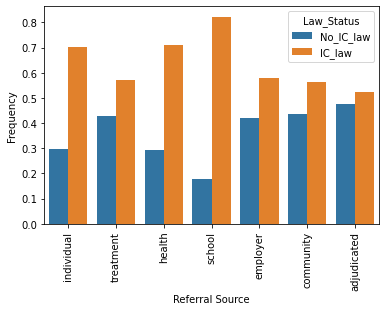

```python
plt.xticks(rotation=90)
sns.barplot(
    data=pd.melt(
        totals.div(totals.sum(axis=0), axis=1).reset_index(),
        id_vars = 'IC_law',
        value_vars = ['individual', 'treatment', 'health', 'school', 'employer', 'community', 'adjudicated'],
        var_name = "Referral Source",
        value_name = "Frequency"
    ).assign(
        Law_Status = lambda x: x.apply(lambda y: 'No_IC_law' if y['IC_law'] == 0 else 'IC_law', axis=1)
    ),
    x="Referral Source",
    y="Frequency",
    hue="Law_Status",

)
```

**Total Cases in Each Category by IC Law, for Methamphetamine Patients**

```python
met_cases = teds_laws.met_cases == 1
totals=teds_laws.loc[met_cases,['IC_law', 'PSOURCE']].assign(
    individual = lambda x: x.loc[:,['PSOURCE']].apply(lambda x: x['PSOURCE'] == 1, axis=1),
    treatment = lambda x: x.loc[:,['PSOURCE']].apply(lambda x: x['PSOURCE'] == 2, axis=1),
    health = lambda x: x.loc[:,['PSOURCE']].apply(lambda x: x['PSOURCE'] == 3, axis=1),
    school = lambda x: x.loc[:,['PSOURCE']].apply(lambda x: x['PSOURCE'] == 4, axis=1),
    employer = lambda x: x.loc[:,['PSOURCE']].apply(lambda x: x['PSOURCE'] == 5, axis=1),
    community = lambda x: x.loc[:,['PSOURCE']].apply(lambda x: x['PSOURCE'] == 6, axis=1),
    adjudicated = lambda x: x.loc[:,['PSOURCE']].apply(lambda x: x['PSOURCE'] == 7, axis=1)
).groupby(['IC_law']).sum().drop(columns=['PSOURCE'])
totals
```

| IC_law | individual | treatment | health | school | employer | community | adjudicated |
| --- | --- | --- | --- | --- | --- | --- | --- |
| 0 | 6292 | 939 | 1607 | 23 | 38 | 2735 | 9487 |
| 1 | 27563 | 6908 | 7918 | 105 | 133 | 13292 | 37045 |

**Methamphetamine Patients: Proportion Cases in each referal category by IC Laws**

```python
 totals.div(totals.sum(axis=1), axis=0).reset_index()
```

|  | IC_law | individual | treatment | health | school | employer | community | adjudicated |
| --- | --- | --- | --- | --- | --- | --- | --- | --- |
| 0 | 0 | 0.297903 | 0.044458 | 0.076085 | 0.001089 | 0.001799 | 0.129492 | 0.449174 |
| 1 | 1 | 0.296491 | 0.074308 | 0.085173 | 0.001129 | 0.001431 | 0.142980 | 0.398488 |

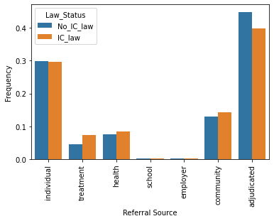

```python
plt.xticks(rotation=90)
sns.barplot(
    data=pd.melt(
        totals.div(totals.sum(axis=1), axis=0).reset_index(),
        id_vars = 'IC_law',
        value_vars = ['individual', 'treatment', 'health', 'school', 'employer', 'community', 'adjudicated'],
        var_name = "Referral Source",
        value_name = "Frequency"
    ).assign(
        Law_Status = lambda x: x.apply(lambda y: 'No_IC_law' if y['IC_law'] == 0 else 'IC_law', axis=1)
    ),
    x="Referral Source",
    y="Frequency",
    hue="Law_Status",

)
```

**Methamphetamine Patients: Proportion of cases in each Referal category that are subject to IC Laws**

```python
totals.div(totals.sum(axis=0), axis=1).reset_index()
```

|  | IC_law | individual | treatment | health | school | employer | community | adjudicated |
| --- | --- | --- | --- | --- | --- | --- | --- | --- |
| 0 | 0 | 0.185851 | 0.119664 | 0.168714 | 0.179688 | 0.222222 | 0.17065 | 0.203881 |
| 1 | 1 | 0.814149 | 0.880336 | 0.831286 | 0.820312 | 0.777778 | 0.82935 | 0.796119 |

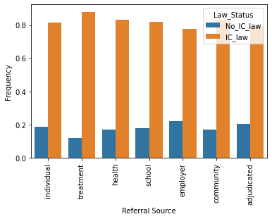

```python
plt.xticks(rotation=90)
sns.barplot(
    data=pd.melt(
        totals.div(totals.sum(axis=0), axis=1).reset_index(),
        id_vars = 'IC_law',
        value_vars = ['individual', 'treatment', 'health', 'school', 'employer', 'community', 'adjudicated'],
        var_name = "Referral Source",
        value_name = "Frequency"
    ).assign(
        Law_Status = lambda x: x.apply(lambda y: 'No_IC_law' if y['IC_law'] == 0 else 'IC_law', axis=1)
    ),
    x="Referral Source",
    y="Frequency",
    hue="Law_Status",

)
```

### Distibution of SERVICES by IC Law Status

**Total Cases in Each Category by IC Law, for Alcohol Patients**

```python
totals=teds_imp_laws.loc[alc_cases,['IC_law', 'SERVICES']].assign(
    Detox_24H_Inpt = lambda x: x.loc[:,['SERVICES']].apply(lambda x: x['SERVICES'] == 1, axis=1),
    Detox_24H_Res = lambda x: x.loc[:,['SERVICES']].apply(lambda x: x['SERVICES'] == 2, axis=1),
    Rehab_Non_Detox = lambda x: x.loc[:,['SERVICES']].apply(lambda x: x['SERVICES'] == 3, axis=1),
    Rehab_30_Day = lambda x: x.loc[:,['SERVICES']].apply(lambda x: x['SERVICES'] == 4, axis=1),
    Rehab_Extended = lambda x: x.loc[:,['SERVICES']].apply(lambda x: x['SERVICES'] == 5, axis=1),
    Ambulatory_Int = lambda x: x.loc[:,['SERVICES']].apply(lambda x: x['SERVICES'] == 6, axis=1),
    Ambulatory_NonInt = lambda x: x.loc[:,['SERVICES']].apply(lambda x: x['SERVICES'] == 7, axis=1),
    Ambulatory_Detox = lambda x: x.loc[:,['SERVICES']].apply(lambda x: x['SERVICES'] == 7, axis=1)
).groupby(['IC_law']).sum().drop(columns=['SERVICES'])
totals
```

| IC_law | Detox_24H_Inpt | Detox_24H_Res | Rehab_Non_Detox | Rehab_30_Day | Rehab_Extended | Ambulatory_Int | Ambulatory_NonInt | Ambulatory_Detox |
| --- | --- | --- | --- | --- | --- | --- | --- | --- |
| 0 | 48 | 6812 | 42 | 20221 | 8434 | 12525 | 59063 | 59063 |
| 1 | 2687 | 57553 | 1057 | 30867 | 16929 | 50502 | 123637 | 123637 |

**Alcohol Patients: Proportion Cases in each service category by IC Laws**

```python
 totals.div(totals.sum(axis=1), axis=0).reset_index()
```

|  | IC_law | Detox_24H_Inpt | Detox_24H_Res | Rehab_Non_Detox | Rehab_30_Day | Rehab_Extended | Ambulatory_Int | Ambulatory_NonInt | Ambulatory_Detox |
| --- | --- | --- | --- | --- | --- | --- | --- | --- | --- |
| 0 | 0 | 0.000289 | 0.040985 | 0.000253 | 0.121661 | 0.050744 | 0.075357 | 0.355356 | 0.355356 |
| 1 | 1 | 0.006604 | 0.141453 | 0.002598 | 0.075865 | 0.041608 | 0.124123 | 0.303874 | 0.303874 |

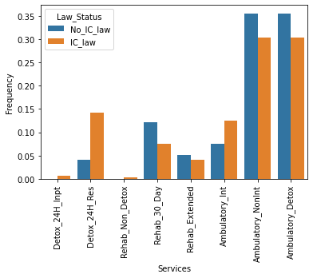

```python
plt.xticks(rotation=90)
sns.barplot(
    data=pd.melt(
        totals.div(totals.sum(axis=1), axis=0).reset_index(),
        id_vars = 'IC_law',
        value_vars = [
            'Detox_24H_Inpt','Detox_24H_Res','Rehab_Non_Detox',
            'Rehab_30_Day','Rehab_Extended','Ambulatory_Int',
            'Ambulatory_NonInt','Ambulatory_Detox'
        ],
        var_name = "Services",
        value_name = "Frequency"
    ).assign(
        Law_Status = lambda x: x.apply(lambda y: 'No_IC_law' if y['IC_law'] == 0 else 'IC_law', axis=1)
    ),
    x="Services",
    y="Frequency",
    hue="Law_Status",

)
```

**Alcohol Patients: Proportion of cases in each Service category that are subject to IC Laws**

```python
totals.div(totals.sum(axis=0), axis=1).reset_index()
```

|  | IC_law | Detox_24H_Inpt | Detox_24H_Res | Rehab_Non_Detox | Rehab_30_Day | Rehab_Extended | Ambulatory_Int | Ambulatory_NonInt | Ambulatory_Detox |
| --- | --- | --- | --- | --- | --- | --- | --- | --- | --- |
| 0 | 0 | 0.01755 | 0.105834 | 0.038217 | 0.395807 | 0.332532 | 0.198724 | 0.323279 | 0.323279 |
| 1 | 1 | 0.98245 | 0.894166 | 0.961783 | 0.604193 | 0.667468 | 0.801276 | 0.676721 | 0.676721 |

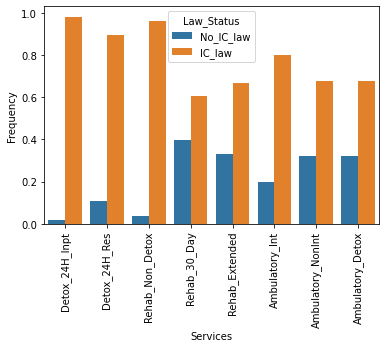

```python
plt.xticks(rotation=90)
sns.barplot(
    data=pd.melt(
        totals.div(totals.sum(axis=0), axis=1).reset_index(),
        id_vars = 'IC_law',
            value_vars = [
            'Detox_24H_Inpt','Detox_24H_Res','Rehab_Non_Detox',
            'Rehab_30_Day','Rehab_Extended','Ambulatory_Int',
            'Ambulatory_NonInt','Ambulatory_Detox'
        ],
        var_name = "Services",
        value_name = "Frequency"
    ).assign(
        Law_Status = lambda x: x.apply(lambda y: 'No_IC_law' if y['IC_law'] == 0 else 'IC_law', axis=1)
    ),
    x="Services",
    y="Frequency",
    hue="Law_Status",

)
```

**Total Cases in Each Category by IC Law, for Heroin Patients**

```python
totals=teds_imp_laws.loc[hrn_cases,['IC_law', 'SERVICES']].assign(
    individual = lambda x: x.loc[:,['SERVICES']].apply(lambda x: x['SERVICES'] == 1, axis=1),
    treatment = lambda x: x.loc[:,['SERVICES']].apply(lambda x: x['SERVICES'] == 2, axis=1),
    health = lambda x: x.loc[:,['SERVICES']].apply(lambda x: x['SERVICES'] == 3, axis=1),
    school = lambda x: x.loc[:,['SERVICES']].apply(lambda x: x['SERVICES'] == 4, axis=1),
    employer = lambda x: x.loc[:,['SERVICES']].apply(lambda x: x['SERVICES'] == 5, axis=1),
    community = lambda x: x.loc[:,['SERVICES']].apply(lambda x: x['SERVICES'] == 6, axis=1),
    adjudicated = lambda x: x.loc[:,['SERVICES']].apply(lambda x: x['SERVICES'] == 7, axis=1)
).groupby(['IC_law']).sum().drop(columns=['SERVICES'])
totals
```

| IC_law | individual | treatment | health | school | employer | community | adjudicated |
| --- | --- | --- | --- | --- | --- | --- | --- |
| 0 | 42 | 2245 | 55 | 22278 | 10191 | 7379 | 68714 |
| 1 | 1737 | 42092 | 826 | 18320 | 12390 | 31914 | 78766 |

```python
 totals.div(totals.sum(axis=1), axis=0).reset_index()
```

|  | IC_law | individual | treatment | health | school | employer | community | adjudicated |
| --- | --- | --- | --- | --- | --- | --- | --- | --- |
| 0 | 0 | 0.000379 | 0.020243 | 0.000496 | 0.200876 | 0.091890 | 0.066535 | 0.619581 |
| 1 | 1 | 0.009336 | 0.226246 | 0.004440 | 0.098471 | 0.066597 | 0.171539 | 0.423371 |

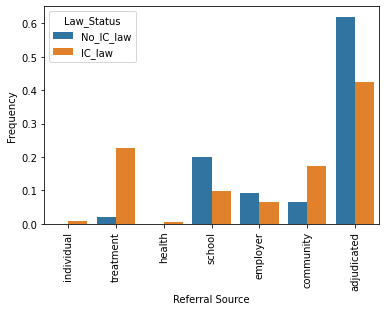

```python
plt.xticks(rotation=90)
sns.barplot(
    data=pd.melt(
        totals.div(totals.sum(axis=1), axis=0).reset_index(),
        id_vars = 'IC_law',
        value_vars = ['individual', 'treatment', 'health', 'school', 'employer', 'community', 'adjudicated'],
        var_name = "Referral Source",
        value_name = "Frequency"
    ).assign(
        Law_Status = lambda x: x.apply(lambda y: 'No_IC_law' if y['IC_law'] == 0 else 'IC_law', axis=1)
    ),
    x="Referral Source",
    y="Frequency",
    hue="Law_Status"
)
```

```python
totals.div(totals.sum(axis=0), axis=1).reset_index()
```

|  | IC_law | individual | treatment | health | school | employer | community | adjudicated |
| --- | --- | --- | --- | --- | --- | --- | --- | --- |
| 0 | 0 | 0.023609 | 0.050635 | 0.062429 | 0.548746 | 0.451309 | 0.187794 | 0.465921 |
| 1 | 1 | 0.976391 | 0.949365 | 0.937571 | 0.451254 | 0.548691 | 0.812206 | 0.534079 |

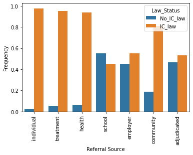

```python
plt.xticks(rotation=90)
sns.barplot(
    data=pd.melt(
        totals.div(totals.sum(axis=0), axis=1).reset_index(),
        id_vars = 'IC_law',
        value_vars = ['individual', 'treatment', 'health', 'school', 'employer', 'community', 'adjudicated'],
        var_name = "Referral Source",
        value_name = "Frequency"
    ).assign(
        Law_Status = lambda x: x.apply(lambda y: 'No_IC_law' if y['IC_law'] == 0 else 'IC_law', axis=1)
    ),
    x="Referral Source",
    y="Frequency",
    hue="Law_Status"
)
```

**Total Cases in Each Category by IC Law, for Methamphetamine Patients**

```python
totals=teds_imp_laws.loc[met_cases,['IC_law', 'SERVICES']].assign(
    individual = lambda x: x.loc[:,['SERVICES']].apply(lambda x: x['SERVICES'] == 1, axis=1),
    treatment = lambda x: x.loc[:,['SERVICES']].apply(lambda x: x['SERVICES'] == 2, axis=1),
    health = lambda x: x.loc[:,['SERVICES']].apply(lambda x: x['SERVICES'] == 3, axis=1),
    school = lambda x: x.loc[:,['SERVICES']].apply(lambda x: x['SERVICES'] == 4, axis=1),
    employer = lambda x: x.loc[:,['SERVICES']].apply(lambda x: x['SERVICES'] == 5, axis=1),
    community = lambda x: x.loc[:,['SERVICES']].apply(lambda x: x['SERVICES'] == 6, axis=1),
    adjudicated = lambda x: x.loc[:,['SERVICES']].apply(lambda x: x['SERVICES'] == 7, axis=1)
).groupby(['IC_law']).sum().drop(columns=['SERVICES'])
totals
```

| IC_law | individual | treatment | health | school | employer | community | adjudicated |
| --- | --- | --- | --- | --- | --- | --- | --- |
| 0 | 24 | 3071 | 29 | 4416 | 1298 | 4736 | 15079 |
| 1 | 738 | 12748 | 190 | 8836 | 4685 | 15214 | 42062 |

```python
 totals.div(totals.sum(axis=1), axis=0).reset_index()
```

|  | IC_law | individual | treatment | health | school | employer | community | adjudicated |
| --- | --- | --- | --- | --- | --- | --- | --- | --- |
| 0 | 0 | 0.000838 | 0.107179 | 0.001012 | 0.154120 | 0.045301 | 0.165288 | 0.526263 |
| 1 | 1 | 0.008737 | 0.150912 | 0.002249 | 0.104601 | 0.055462 | 0.180105 | 0.497934 |

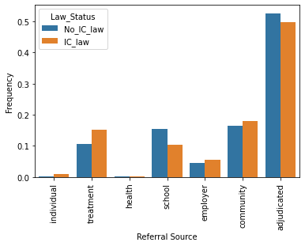

```python
plt.xticks(rotation=90)
sns.barplot(
    data=pd.melt(
        totals.div(totals.sum(axis=1), axis=0).reset_index(),
        id_vars = 'IC_law',
        value_vars = ['individual', 'treatment', 'health', 'school', 'employer', 'community', 'adjudicated'],
        var_name = "Referral Source",
        value_name = "Frequency"
    ).assign(
        Law_Status = lambda x: x.apply(lambda y: 'No_IC_law' if y['IC_law'] == 0 else 'IC_law', axis=1)
    ),
    x="Referral Source",
    y="Frequency",
    hue="Law_Status"
)
```

```python
totals.div(totals.sum(axis=0), axis=1).reset_index()
```

|  | IC_law | individual | treatment | health | school | employer | community | adjudicated |
| --- | --- | --- | --- | --- | --- | --- | --- | --- |
| 0 | 0 | 0.031496 | 0.194134 | 0.13242 | 0.333233 | 0.216948 | 0.237393 | 0.263891 |
| 1 | 1 | 0.968504 | 0.805866 | 0.86758 | 0.666767 | 0.783052 | 0.762607 | 0.736109 |

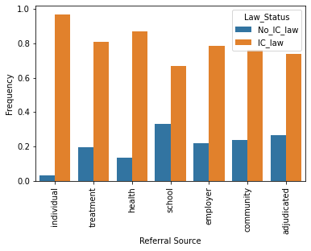

```python
plt.xticks(rotation=90)
sns.barplot(
    data=pd.melt(
        totals.div(totals.sum(axis=0), axis=1).reset_index(),
        id_vars = 'IC_law',
        value_vars = ['individual', 'treatment', 'health', 'school', 'employer', 'community', 'adjudicated'],
        var_name = "Referral Source",
        value_name = "Frequency"
    ).assign(
        Law_Status = lambda x: x.apply(lambda y: 'No_IC_law' if y['IC_law'] == 0 else 'IC_law', axis=1)
    ),
    x="Referral Source",
    y="Frequency",
    hue="Law_Status"
)
```

### Distribution ofReason For Termination by IC Law Status

**Alcohol Patients: Proportion Cases in each dischrage category by IC Laws**

```python
alc_cases = teds_laws.alc_cases == 1
totals=teds_laws.loc[alc_cases,['IC_law', 'REASON']].assign(
    Completed = lambda x: x.loc[:,['REASON']].apply(lambda x: x['REASON'] == 1, axis=1),
    Dropout = lambda x: x.loc[:,['REASON']].apply(lambda x: x['REASON'] == 2, axis=1),
    Terminated = lambda x: x.loc[:,['REASON']].apply(lambda x: x['REASON'] == 3, axis=1),
    Transferred = lambda x: x.loc[:,['REASON']].apply(lambda x: x['REASON'] == 4, axis=1),
    Incarcerated = lambda x: x.loc[:,['REASON']].apply(lambda x: x['REASON'] == 5, axis=1),
    Death = lambda x: x.loc[:,['REASON']].apply(lambda x: x['REASON'] == 6, axis=1),
    Other = lambda x: x.loc[:,['REASON']].apply(lambda x: x['REASON'] == 7, axis=1)
).groupby(['IC_law']).sum().drop(columns=['REASON'])
totals
```

| IC_law | Completed | Dropout | Terminated | Transferred | Incarcerated | Death | Other |
| --- | --- | --- | --- | --- | --- | --- | --- |
| 0 | 56431 | 30372 | 7564 | 9632 | 2258 | 316 | 3877 |
| 1 | 146026 | 50506 | 12668 | 58439 | 2657 | 367 | 11070 |

```python
 totals.div(totals.sum(axis=1), axis=0).reset_index()
```

|  | IC_law | Completed | Dropout | Terminated | Transferred | Incarcerated | Death | Other |
| --- | --- | --- | --- | --- | --- | --- | --- | --- |
| 0 | 0 | 0.510919 | 0.274984 | 0.068483 | 0.087207 | 0.020444 | 0.002861 | 0.035102 |
| 1 | 1 | 0.518313 | 0.179269 | 0.044965 | 0.207427 | 0.009431 | 0.001303 | 0.039293 |

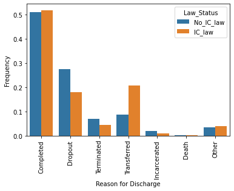

```python
plt.xticks(rotation=90)
sns.barplot(
    data=pd.melt(
        totals.div(totals.sum(axis=1), axis=0).reset_index(),
        id_vars = 'IC_law',
        value_vars = ['Completed', 'Dropout', 'Terminated', 'Transferred', 'Incarcerated', 'Death', 'Other'],
        var_name = "Reason for Discharge",
        value_name = "Frequency"
    ).assign(
        Law_Status = lambda x: x.apply(lambda y: 'No_IC_law' if y['IC_law'] == 0 else 'IC_law', axis=1)
    ),
    x="Reason for Discharge",
    y="Frequency",
    hue="Law_Status",

)
```

**Alcohol Patients: Proportion of cases in each discharge category that are subject to IC Laws**

```python
totals.div(totals.sum(axis=0), axis=1).reset_index()
```

|  | IC_law | Completed | Dropout | Terminated | Transferred | Incarcerated | Death | Other |
| --- | --- | --- | --- | --- | --- | --- | --- | --- |
| 0 | 0 | 0.278731 | 0.375529 | 0.373863 | 0.141499 | 0.45941 | 0.462665 | 0.259383 |
| 1 | 1 | 0.721269 | 0.624471 | 0.626137 | 0.858501 | 0.54059 | 0.537335 | 0.740617 |

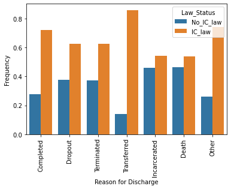

```python
plt.xticks(rotation=90)
sns.barplot(
    data=pd.melt(
        totals.div(totals.sum(axis=0), axis=1).reset_index(),
        id_vars = 'IC_law',
        value_vars = ['Completed', 'Dropout', 'Terminated', 'Transferred', 'Incarcerated', 'Death', 'Other'],
        var_name = "Reason for Discharge",
        value_name = "Frequency"
    ).assign(
        Law_Status = lambda x: x.apply(lambda y: 'No_IC_law' if y['IC_law'] == 0 else 'IC_law', axis=1)
    ),
    x="Reason for Discharge",
    y="Frequency",
    hue="Law_Status",

)
```

**Heroin Patients: Proportion Cases in each dischrage category by IC Laws**

```python
hrn_cases = teds_laws.hrn_cases == 1
totals=teds_laws.loc[hrn_cases,['IC_law', 'REASON']].assign(
    Completed = lambda x: x.loc[:,['REASON']].apply(lambda x: x['REASON'] == 1, axis=1),
    Dropout = lambda x: x.loc[:,['REASON']].apply(lambda x: x['REASON'] == 2, axis=1),
    Terminated = lambda x: x.loc[:,['REASON']].apply(lambda x: x['REASON'] == 3, axis=1),
    Transferred = lambda x: x.loc[:,['REASON']].apply(lambda x: x['REASON'] == 4, axis=1),
    Incarcerated = lambda x: x.loc[:,['REASON']].apply(lambda x: x['REASON'] == 5, axis=1),
    Death = lambda x: x.loc[:,['REASON']].apply(lambda x: x['REASON'] == 6, axis=1),
    Other = lambda x: x.loc[:,['REASON']].apply(lambda x: x['REASON'] == 7, axis=1)
).groupby(['IC_law']).sum().drop(columns=['REASON'])
totals
```

| IC_law | Completed | Dropout | Terminated | Transferred | Incarcerated | Death | Other |
| --- | --- | --- | --- | --- | --- | --- | --- |
| 0 | 39363 | 33889 | 10198 | 14159 | 3625 | 707 | 5470 |
| 1 | 62851 | 50092 | 13654 | 52010 | 3163 | 566 | 8320 |

```python
 totals.div(totals.sum(axis=1), axis=0).reset_index()
```

|  | IC_law | Completed | Dropout | Terminated | Transferred | Incarcerated | Death | Other |
| --- | --- | --- | --- | --- | --- | --- | --- | --- |
| 0 | 0 | 0.366471 | 0.315508 | 0.094944 | 0.131821 | 0.033749 | 0.006582 | 0.050926 |
| 1 | 1 | 0.329657 | 0.262735 | 0.071616 | 0.272795 | 0.016590 | 0.002969 | 0.043639 |

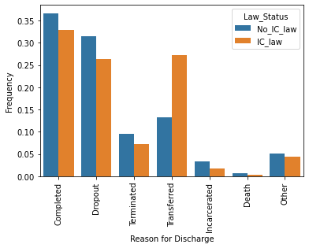

```python
plt.xticks(rotation=90)
sns.barplot(
    data=pd.melt(
        totals.div(totals.sum(axis=1), axis=0).reset_index(),
        id_vars = 'IC_law',
        value_vars = ['Completed', 'Dropout', 'Terminated', 'Transferred', 'Incarcerated', 'Death', 'Other'],
        var_name = "Reason for Discharge",
        value_name = "Frequency"
    ).assign(
        Law_Status = lambda x: x.apply(lambda y: 'No_IC_law' if y['IC_law'] == 0 else 'IC_law', axis=1)
    ),
    x="Reason for Discharge",
    y="Frequency",
    hue="Law_Status",

)
```

**Heroin Patients: Proportion of cases in each discharge category that are subject to IC Laws**

```python
totals.div(totals.sum(axis=0), axis=1).reset_index()
```

|  | IC_law | Completed | Dropout | Terminated | Transferred | Incarcerated | Death | Other |
| --- | --- | --- | --- | --- | --- | --- | --- | --- |
| 0 | 0 | 0.385104 | 0.403532 | 0.427553 | 0.213982 | 0.534031 | 0.555381 | 0.396664 |
| 1 | 1 | 0.614896 | 0.596468 | 0.572447 | 0.786018 | 0.465969 | 0.444619 | 0.603336 |

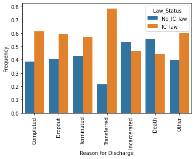

```python
plt.xticks(rotation=90)
sns.barplot(
    data=pd.melt(
        totals.div(totals.sum(axis=0), axis=1).reset_index(),
        id_vars = 'IC_law',
        value_vars = ['Completed', 'Dropout', 'Terminated', 'Transferred', 'Incarcerated', 'Death', 'Other'],
        var_name = "Reason for Discharge",
        value_name = "Frequency"
    ).assign(
        Law_Status = lambda x: x.apply(lambda y: 'No_IC_law' if y['IC_law'] == 0 else 'IC_law', axis=1)
    ),
    x="Reason for Discharge",
    y="Frequency",
    hue="Law_Status",

)
```

```python
met_cases = teds_laws.met_cases == 1
totals=teds_laws.loc[hrn_cases,['IC_law', 'REASON']].assign(
    Completed = lambda x: x.loc[:,['REASON']].apply(lambda x: x['REASON'] == 1, axis=1),
    Dropout = lambda x: x.loc[:,['REASON']].apply(lambda x: x['REASON'] == 2, axis=1),
    Terminated = lambda x: x.loc[:,['REASON']].apply(lambda x: x['REASON'] == 3, axis=1),
    Transferred = lambda x: x.loc[:,['REASON']].apply(lambda x: x['REASON'] == 4, axis=1),
    Incarcerated = lambda x: x.loc[:,['REASON']].apply(lambda x: x['REASON'] == 5, axis=1),
    Death = lambda x: x.loc[:,['REASON']].apply(lambda x: x['REASON'] == 6, axis=1),
    Other = lambda x: x.loc[:,['REASON']].apply(lambda x: x['REASON'] == 7, axis=1)
).groupby(['IC_law']).sum().drop(columns=['REASON'])
totals
```

| IC_law | Completed | Dropout | Terminated | Transferred | Incarcerated | Death | Other |
| --- | --- | --- | --- | --- | --- | --- | --- |
| 0 | 39363 | 33889 | 10198 | 14159 | 3625 | 707 | 5470 |
| 1 | 62851 | 50092 | 13654 | 52010 | 3163 | 566 | 8320 |

```python
 totals.div(totals.sum(axis=1), axis=0).reset_index()
```

|  | IC_law | Completed | Dropout | Terminated | Transferred | Incarcerated | Death | Other |
| --- | --- | --- | --- | --- | --- | --- | --- | --- |
| 0 | 0 | 0.366471 | 0.315508 | 0.094944 | 0.131821 | 0.033749 | 0.006582 | 0.050926 |
| 1 | 1 | 0.329657 | 0.262735 | 0.071616 | 0.272795 | 0.016590 | 0.002969 | 0.043639 |

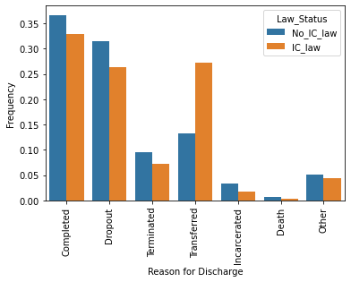

```python
plt.xticks(rotation=90)
sns.barplot(
    data=pd.melt(
        totals.div(totals.sum(axis=1), axis=0).reset_index(),
        id_vars = 'IC_law',
        value_vars = ['Completed', 'Dropout', 'Terminated', 'Transferred', 'Incarcerated', 'Death', 'Other'],
        var_name = "Reason for Discharge",
        value_name = "Frequency"
    ).assign(
        Law_Status = lambda x: x.apply(lambda y: 'No_IC_law' if y['IC_law'] == 0 else 'IC_law', axis=1)
    ),
    x="Reason for Discharge",
    y="Frequency",
    hue="Law_Status",

)
```

```python
totals.div(totals.sum(axis=0), axis=1).reset_index()
```

|  | IC_law | Completed | Dropout | Terminated | Transferred | Incarcerated | Death | Other |
| --- | --- | --- | --- | --- | --- | --- | --- | --- |
| 0 | 0 | 0.385104 | 0.403532 | 0.427553 | 0.213982 | 0.534031 | 0.555381 | 0.396664 |
| 1 | 1 | 0.614896 | 0.596468 | 0.572447 | 0.786018 | 0.465969 | 0.444619 | 0.603336 |

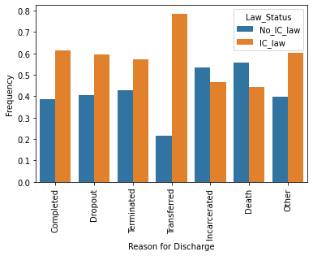

```python
plt.xticks(rotation=90)
sns.barplot(
    data=pd.melt(
        totals.div(totals.sum(axis=0), axis=1).reset_index(),
        id_vars = 'IC_law',
        value_vars = ['Completed', 'Dropout', 'Terminated', 'Transferred', 'Incarcerated', 'Death', 'Other'],
        var_name = "Reason for Discharge",
        value_name = "Frequency"
    ).assign(
        Law_Status = lambda x: x.apply(lambda y: 'No_IC_law' if y['IC_law'] == 0 else 'IC_law', axis=1)
    ),
    x="Reason for Discharge",
    y="Frequency",
    hue="Law_Status",

)
```

### Pregnancy (In Female Patients)

**Alcohol Patients: Proportion Pregnant Cases by IC Laws**

```python
fem_alc_cases = teds_laws[
    (teds_laws['alc_cases'] == 1) & (~pd.isna(teds_laws.PREG))
].index
teds_laws.loc[fem_alc_cases,:].shape
```

```
(106983, 142)
```

```python
totals=teds_laws.loc[fem_alc_cases,['IC_Circumstances_Protect an unborn child', 'PREG']].assign(
    Pregnant = lambda x: x.loc[:,['PREG']].apply(lambda x: x['PREG'] == 1, axis=1),
    Not_Pregnant = lambda x: x.loc[:,['PREG']].apply(lambda x: x['PREG'] == 2, axis=1)
).groupby(['IC_Circumstances_Protect an unborn child']).sum().drop(columns=['PREG'])
totals
```

| IC_Circumstances_Protect an unborn child | Pregnant | Not_Pregnant |
| --- | --- | --- |
| 0.0 | 1079 | 75745 |
| 1.0 | 34 | 2225 |

```python
 totals.div(totals.sum(axis=1), axis=0).reset_index()
```

|  | IC_Circumstances_Protect an unborn child | Pregnant | Not_Pregnant |
| --- | --- | --- | --- |
| 0 | 0.0 | 0.014045 | 0.985955 |
| 1 | 1.0 | 0.015051 | 0.984949 |

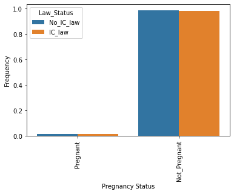

```python
plt.xticks(rotation=90)
sns.barplot(
    data=pd.melt(
        totals.div(totals.sum(axis=1), axis=0).reset_index(),
        id_vars = 'IC_Circumstances_Protect an unborn child',
        value_vars = ['Pregnant', 'Not_Pregnant'],
        var_name = "Pregnancy Status",
        value_name = "Frequency"
    ).assign(
        Law_Status = lambda x: x.apply(lambda y: 'No_IC_law' if y['IC_Circumstances_Protect an unborn child'] == 0 else 'IC_law', axis=1)
    ),
    x="Pregnancy Status",
    y="Frequency",
    hue="Law_Status",

)
```

```python
 totals.div(totals.sum(axis=0), axis=1).reset_index()
```

|  | IC_Circumstances_Protect an unborn child | Pregnant | Not_Pregnant |
| --- | --- | --- | --- |
| 0 | 0.0 | 0.969452 | 0.971463 |
| 1 | 1.0 | 0.030548 | 0.028537 |

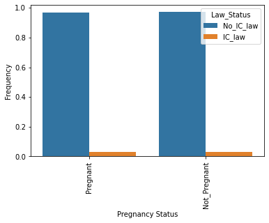

```python
plt.xticks(rotation=90)
sns.barplot(
    data=pd.melt(
        totals.div(totals.sum(axis=0), axis=1).reset_index(),
        id_vars = 'IC_Circumstances_Protect an unborn child',
        value_vars = ['Pregnant', 'Not_Pregnant'],
        var_name = "Pregnancy Status",
        value_name = "Frequency"
    ).assign(
        Law_Status = lambda x: x.apply(lambda y: 'No_IC_law' if y['IC_Circumstances_Protect an unborn child'] == 0 else 'IC_law', axis=1)
    ),
    x="Pregnancy Status",
    y="Frequency",
    hue="Law_Status",

)
```

```python
fem_hrn_cases = teds_laws[
    (teds_laws['hrn_cases'] == 1) & (~pd.isna(teds_laws.PREG))
].index
teds_laws.loc[fem_hrn_cases,:].shape
```

```
(99794, 142)
```

```python
totals=teds_laws.loc[fem_hrn_cases,['IC_Circumstances_Protect an unborn child', 'PREG']].assign(
    Pregnant = lambda x: x.loc[:,['PREG']].apply(lambda x: x['PREG'] == 1, axis=1),
    Not_Pregnant = lambda x: x.loc[:,['PREG']].apply(lambda x: x['PREG'] == 2, axis=1)
).groupby(['IC_Circumstances_Protect an unborn child']).sum().drop(columns=['PREG'])
totals
```

| IC_Circumstances_Protect an unborn child | Pregnant | Not_Pregnant |
| --- | --- | --- |
| 0.0 | 3009 | 65800 |
| 1.0 | 1 | 43 |

```python
 totals.div(totals.sum(axis=1), axis=0).reset_index()
```

|  | IC_Circumstances_Protect an unborn child | Pregnant | Not_Pregnant |
| --- | --- | --- | --- |
| 0 | 0.0 | 0.043730 | 0.956270 |
| 1 | 1.0 | 0.022727 | 0.977273 |

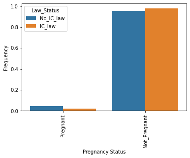

```python
plt.xticks(rotation=90)
sns.barplot(
    data=pd.melt(
        totals.div(totals.sum(axis=1), axis=0).reset_index(),
        id_vars = 'IC_Circumstances_Protect an unborn child',
        value_vars = ['Pregnant', 'Not_Pregnant'],
        var_name = "Pregnancy Status",
        value_name = "Frequency"
    ).assign(
        Law_Status = lambda x: x.apply(lambda y: 'No_IC_law' if y['IC_Circumstances_Protect an unborn child'] == 0 else 'IC_law', axis=1)
    ),
    x="Pregnancy Status",
    y="Frequency",
    hue="Law_Status",

)
```

```python
 totals.div(totals.sum(axis=0), axis=1).reset_index()
```

|  | IC_Circumstances_Protect an unborn child | Pregnant | Not_Pregnant |
| --- | --- | --- | --- |
| 0 | 0.0 | 0.999668 | 0.999347 |
| 1 | 1.0 | 0.000332 | 0.000653 |

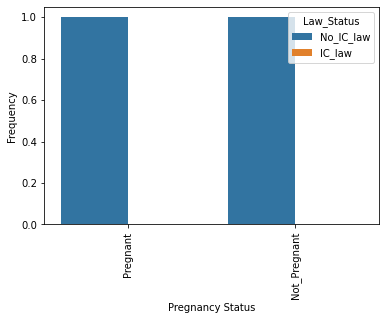

```python
plt.xticks(rotation=90)
sns.barplot(
    data=pd.melt(
        totals.div(totals.sum(axis=0), axis=1).reset_index(),
        id_vars = 'IC_Circumstances_Protect an unborn child',
        value_vars = ['Pregnant', 'Not_Pregnant'],
        var_name = "Pregnancy Status",
        value_name = "Frequency"
    ).assign(
        Law_Status = lambda x: x.apply(lambda y: 'No_IC_law' if y['IC_Circumstances_Protect an unborn child'] == 0 else 'IC_law', axis=1)
    ),
    x="Pregnancy Status",
    y="Frequency",
    hue="Law_Status",

)
```

```python
fem_hrn_cases = teds_laws[
    (teds_laws['hrn_cases'] == 1) & (~pd.isna(teds_laws.PREG))
].index
teds_laws.loc[fem_hrn_cases,:].shape
```

```
(99794, 142)
```

```python
totals=teds_laws.loc[fem_hrn_cases,['IC_Circumstances_Protect an unborn child', 'PREG']].assign(
    Pregnant = lambda x: x.loc[:,['PREG']].apply(lambda x: x['PREG'] == 1, axis=1),
    Not_Pregnant = lambda x: x.loc[:,['PREG']].apply(lambda x: x['PREG'] == 2, axis=1)
).groupby(['IC_Circumstances_Protect an unborn child']).sum().drop(columns=['PREG'])
totals
```

| IC_Circumstances_Protect an unborn child | Pregnant | Not_Pregnant |
| --- | --- | --- |
| 0.0 | 3009 | 65800 |
| 1.0 | 1 | 43 |

```python
 totals.div(totals.sum(axis=1), axis=0).reset_index()
```

|  | IC_Circumstances_Protect an unborn child | Pregnant | Not_Pregnant |
| --- | --- | --- | --- |
| 0 | 0.0 | 0.043730 | 0.956270 |
| 1 | 1.0 | 0.022727 | 0.977273 |

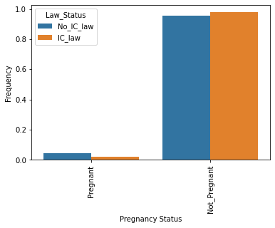

```python
plt.xticks(rotation=90)
sns.barplot(
    data=pd.melt(
        totals.div(totals.sum(axis=1), axis=0).reset_index(),
        id_vars = 'IC_Circumstances_Protect an unborn child',
        value_vars = ['Pregnant', 'Not_Pregnant'],
        var_name = "Pregnancy Status",
        value_name = "Frequency"
    ).assign(
        Law_Status = lambda x: x.apply(lambda y: 'No_IC_law' if y['IC_Circumstances_Protect an unborn child'] == 0 else 'IC_law', axis=1)
    ),
    x="Pregnancy Status",
    y="Frequency",
    hue="Law_Status",

)
```

```python
 totals.div(totals.sum(axis=0), axis=1).reset_index()
```

|  | IC_Circumstances_Protect an unborn child | Pregnant | Not_Pregnant |
| --- | --- | --- | --- |
| 0 | 0.0 | 0.999668 | 0.999347 |
| 1 | 1.0 | 0.000332 | 0.000653 |

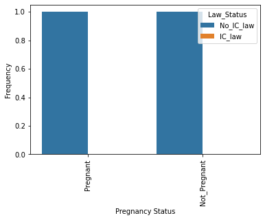

```python
plt.xticks(rotation=90)
sns.barplot(
    data=pd.melt(
        totals.div(totals.sum(axis=0), axis=1).reset_index(),
        id_vars = 'IC_Circumstances_Protect an unborn child',
        value_vars = ['Pregnant', 'Not_Pregnant'],
        var_name = "Pregnancy Status",
        value_name = "Frequency"
    ).assign(
        Law_Status = lambda x: x.apply(lambda y: 'No_IC_law' if y['IC_Circumstances_Protect an unborn child'] == 0 else 'IC_law', axis=1)
    ),
    x="Pregnancy Status",
    y="Frequency",
    hue="Law_Status",

)
```